# Breve introducción a la programación

### Un mapa sismológico de Sudamérica

Si vives en Chile, probablemente te habrás dado cuenta que es un país muy sísmico. Tan solo en ésta década hemos tenidos varios terremotos con una magnitud sobre 7 en escala... Cada vez que hay un temblor, los memes vuelan e imploran que se presente Marcelo Lagos a dar el reporte, y hasta un trago se llama Terremoto. Entonces, será verdad que en otras partes del mundo, esto de los sismos no es normal?

Esta pregunta podría ser resuelta si es que visualizamos cada evento registrado desde alguna fecha arbitraria y ver cómo estos se localizan a través de Sudamérica. Para saber esto, hemos consultado la base de datos de la pagina de monitoreo sismológico de la Universidad de Chile (sismologia.cl) entre los años 2003 y 2015, obteniendo una lista con más de 58 mil sismos distribuidos a lo largo del continente, veamos qué pasa:

```python
#Leemos el archivo con los sismos
data = pd.read_csv("sismos.csv")
#Vemos qué es lo que dicen las primeras lineas
print data.head()
```

```
  Fecha localFecha UTC      Unnamed: 1  Latitud  Longitud  Profundidad_Km  \
0       1/1/2003 16:26  1/1/2003 19:26  -34.710   -70.174             0.0
1       1/1/2003 14:22  1/1/2003 17:22  -35.112   -71.375            63.1
2       1/1/2003 14:02  1/1/2003 17:02  -31.051   -71.310            64.4
3       1/1/2003 13:25  1/1/2003 16:25  -30.159   -70.141             5.4
4       1/1/2003 12:54  1/1/2003 15:54  -32.138   -71.753            11.0

               Magnitud                  Referencia
0            3.1 Mc GUC  76 km al E de San Fernando
1  2.9 Mc GUC3.1 Ml GUC        44 km al NE de Talca
2  2.9 Mc GUC2.5 Ml GUC   33 km al NO de Combarbalá
3  3.3 Mc GUC2.7 Ml GUC        57 km al E de Vicuña
4  3.6 Mc GUC3.3 Ml GUC     60 km al NO de La Ligua
```

```python
#Entendemos el archivo y le damos el formato adecuado para hacer los gráficos
Latitudes     = data['Latitud'].values
Longitudes    = data['Longitud'].values
Profundidades = data['Profundidad_Km'].values
Magnitudes    = data['Magnitud'].values

#Damos el formato a las magnitudes:
Mag = np.array([Magnitudes[i].split()[0] for i in range(len(Magnitudes))])
Mags = np.zeros(len(Mag))

for i in range(len(Mag)):
    if Mag[i] == "''":
        Mags[i] = 0
    else:
        Mags[i] = float(Mag[i])
```

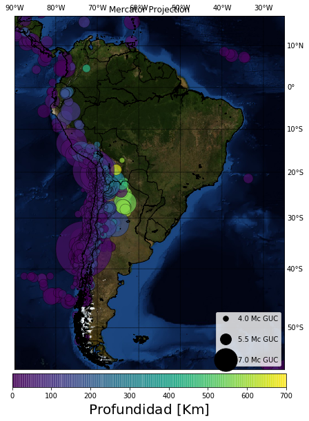

```python
#latitud
x1 = -90.
x2 = -25.

#Longuitud:
y1 = -56.
y2 = 17.

m = Basemap(resolution='h',projection='merc',llcrnrlat=y1,urcrnrlat=y2,llcrnrlon=x1,urcrnrlon=x2,lat_ts=(x1+x2)/2.)
plt.figure(figsize=(6,9))

#Lineas fronterizas de los países
m.drawcoastlines(linewidth=1)
m.drawcountries(linewidth=1)

#Color del mapa del fondo:
m.bluemarble()

#Meridianos y paralelos:
m.drawmeridians(np.arange(0,360,10),labels=[False,True,True,False])
m.drawparallels(np.arange(-90,90,10),labels=[False,True,True,False])

#Mapeamos las coordenadas:
x,y = m(Longitudes, Latitudes)
m.scatter(x, y, s=np.exp(Mags), c=Profundidades,alpha=0.7, edgecolors='black', linewidth=0.45)
cbar = plt.colorbar(orientation='horizontal',pad=0.01)
cbar.set_label(r'${\rm Profundidad\ [Km]}$',size=20)

#Creamos la escala para las magnitudes, recordando que la escala es logaritmica:
for a in [55, 250, 1100]:
    plt.scatter([], [], c='k', alpha=1, s=a,label=str(round(np.log(a),1) ) +' Mc GUC')
plt.legend(scatterpoints=1, frameon=True,labelspacing=2, loc='lower right');

plt.tight_layout()
plt.savefig('mapa_temblores_sudamerica.jpg',format='jpg',dpi=800)
plt.show()
```

https://scipython.com/blog/visualizing-a-vector-field-with-matplotlib/

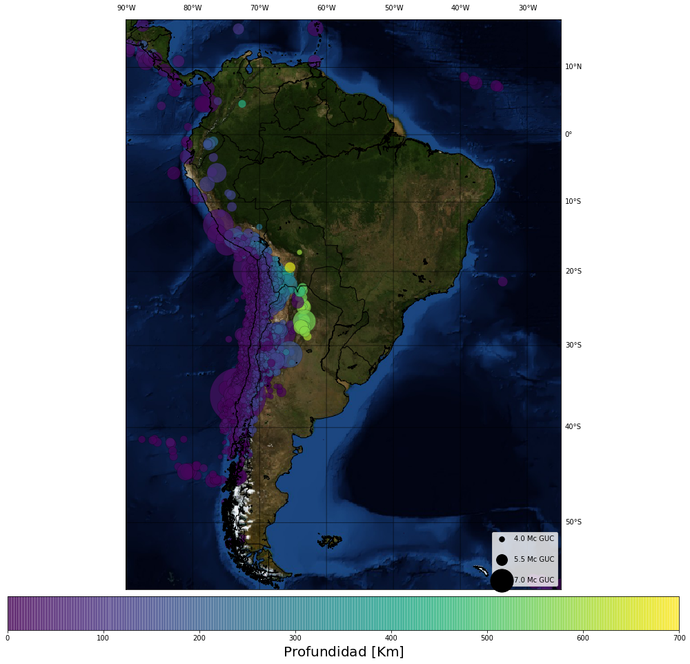

```python
#latitud
x1 = -90.
x2 = -25.

#Longuitud:
y1 = -56.
y2 = 17.



m = Basemap(resolution='h',projection='merc',\
            llcrnrlat=y1,urcrnrlat=y2,llcrnrlon=x1,\
            urcrnrlon=x2,lat_ts=(x1+x2)/2.)

plt.figure(figsize=(14,14))

plt.title("Sismos en Sudamérica entre los años 2003 a 2015")

#Lineas fronterizas
m.drawcoastlines(linewidth=1)
m.drawcountries(linewidth=1)

#Color:
m.bluemarble()

#Meridianos y paralelos:
m.drawmeridians(np.arange(0,360,10),labels=[False,True,True,False])
m.drawparallels(np.arange(-90,90,10),labels=[False,True,True,False])

#Mapeamos las coordenadas:
x,y = m(Longitudes, Latitudes)
m.scatter(x, y, s=np.exp(Mags), c=Profundidades,alpha=0.7, edgecolors='black', linewidth=0.25)
cbar = plt.colorbar(orientation='horizontal',pad=0.01)
cbar.set_label(r'${\rm Profundidad\ [Km]}$',size=20)

#Creamos la escala para las magnitudes, recordando que la escala es logaritmica:
for a in [55, 250, 1100]:
    plt.scatter([], [], c='k', alpha=1, s=a,label=str(round(np.log(a),1) ) +' Mc GUC')
plt.legend(scatterpoints=1, frameon=True,labelspacing=2, loc='lower right');

plt.tight_layout()
plt.savefig('mapa_temblores_sudamerica.jpg',format='jpg',dpi=800)
plt.show()
```

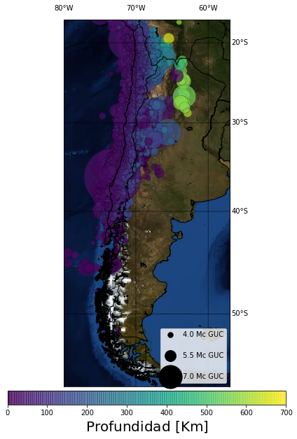

```python
#Enfocamos a Chile:
#latitud
x1 = -80.
x2 = -57.

#Longuitud:
y1 = -56.
y2 = -17.

m = Basemap(resolution='h',projection='merc',llcrnrlat=y1,urcrnrlat=y2,llcrnrlon=x1,urcrnrlon=x2,lat_ts=(x1+x2)/2.)

plt.figure(figsize=(6,9))

#Lineas fronterizas
m.drawcoastlines(linewidth=1)
m.drawcountries(linewidth=1)

#Color:
m.bluemarble()

#Meridianos y paralelos:
m.drawmeridians(np.arange(0,360,10),labels=[False,True,True,False])
m.drawparallels(np.arange(-90,90,10),labels=[False,True,True,False])

#Mapeamos las coordenadas:
x,y = m(Longitudes, Latitudes)
m.scatter(x, y, s=np.exp(Mags), c=Profundidades,alpha=0.7, edgecolors='black', linewidth=0.25)
cbar = plt.colorbar(orientation='horizontal',pad=0.01)
cbar.set_label(r'${\rm Profundidad\ [Km]}$',size=20)

# make legend with dummy points
for a in [55, 250, 1100]:
    plt.scatter([], [], c='k', alpha=1, s=a,label=str(round(np.log(a),1) ) +' Mc GUC')
plt.legend(scatterpoints=1, frameon=True,labelspacing=2, loc='lower right');

plt.tight_layout()
plt.savefig('mapa_temblores_chile.jpg',format='jpg',dpi=500)
plt.show()
```

```python
# Importando paquetes
```

La ciencia (del latín scientĭa ‘conocimiento’) es un sistema ordenado de conocimientos estructurados que estudia, investiga e interpreta los fenómenos naturales, sociales y artificiales. Los conocimientos científicos se obtienen mediante observaciones y experimentaciones en ámbitos específicos, dichos conocimientos deben ser organizados y clasificados sobre la base de principios explicativos ya sean de forma teórica o práctica. A partir de estos se generan preguntas y razonamientos, se construyen hipótesis, se deducen principios y se formulan teorías, leyes generales y sistemas organizados por medio de un método científico.2

La Ciencia es dividida tradicionalmente en una rama experimental y una teórica, pero durante las últimas décadas la computación ha emergido como una parte muy importante de la Ciencia. La computación científica está a menudo muy relacionada con la teoría, pero posee también muchas características comunes con el trabajo experimental. Es por esto que a menudo es vista como una tercera rama de las ciencias. En muchos campos de la Ciencia, el trabajo computacional es un complemento importante tanto para el experimento como para la teoría, y actualmente una gran mayoría de las publicaciones experimentales y teóricas involucran cálculos numéricos, simulaciones y/o modelamiento computacional.

Aprender a programar:

```python
%matplotlib inline
import matplotlib.pyplot as plt
import numpy as np
```

Generaremos una distribución que representará una base de datos la cual necesitamos analizar. Y luego representaremos su distribución mediante un histograma:

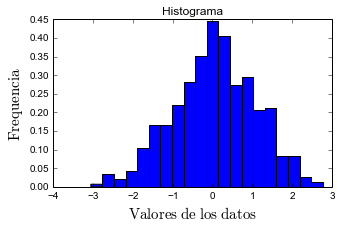

```python
#media y desvio estandar:
mu    = 0
sigma = 1
#Número de datos de la muestra:
Ndatos = 500
#Generamos una muestra de datos:
datos = np.random.normal(mu, sigma, Ndatos)

plt.figure(figsize=(5,3))
frecuencia, largo, ignorar = plt.hist(datos, 20, normed=True)
plt.ylabel(r'$\rm Frequencia$',fontsize=15)
plt.xlabel(r'$\rm Valores\ de\ los\ datos$',fontsize=15)
plt.title('Histograma')
plt.show()
```

## ¿Cómo determinamos que distribución debemos utilizar?

Esta es una muy buena pregunta. De su respuesta depende el modelo que usaremos para entender los datos y sacar conclusiones. Por ende, debemos ser capacez de caracterizar nuestra distribución con el fin de obtener información inicial. Algunas preguntas útiles son si los datos son discretos o continuos, o si la distribución de los valores son simétricos con respecto a un eje. En nuestro caso, como los datos son generados po una distribución Gaussiana, el histograma muestra que los datos son simétricos en el eje $\mu=0$, y sus valores son contínuos.

## Matemáticamente hablando

La función de densidad de probabilidad (PDF por las siglas en inglés Probability Density Function) de la distribución normal, dada la información de un set de mediciones $X=[x_1,x_2,...,x_n]$, se define como sigue:

$$f(X\ |\ \mu,\sigma)=\displaystyle \frac{1}{\sqrt{2\pi} \sigma} \ e^{-\frac{1}{2}\left(\frac{X-\mu}{\sigma}\right)^{2}}$$

```python
def Gaussiana(Distribucion,media,sigma):
    return (1./(np.sqrt(2*np.pi)*sigma))*np.exp(-0.5*((Distribucion - media)/sigma)**2)
```

Entonces, si fijamos los parámetros $\mu=0$ y $\sigma=1$ sobre un rango arbitrario $x_{i}$ que esté centrado en $\mu$ a modo de prueba, podemos ver el comportamiento de la función:

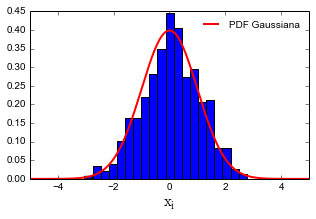

```python
media=0
sigma=1

xi = np.linspace(-5,10,1000)
yi = Gaussiana(xi,media,sigma)

plt.figure(figsize=(5,3))

plt.plot(xi,yi,'-',color='red',linewidth=2, label='PDF Gaussiana')

frecuencia, largo, ignorar = plt.hist(datos, 20, normed=True)

plt.xlim(-5,5)

plt.legend(loc='best', fontsize=10, frameon=False)
plt.xlabel(r'$\rm x_{i}$',fontsize=15)
plt.show()
```

De esta misma manera, podemos estudiar cómo cada uno de esos parámetros afecta a la función $\mathtt{Gaussiana}$. Para cada caso, dejaremos uno de los parámetros fijo y variaremos el otro. En primer lugar, fijaremos $\sigma=1$ y evaluaremos La Funcion gaussiana con $\mu=[0,2,4,6]$ (izquerda). Luego, fijaremos $\mu=0$ y evaluaremos La Funcion gaussiana con $\sigma=[1,1.5,2,3]$ (derecha).

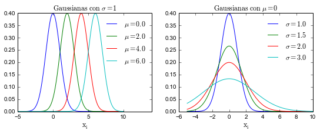

```python
plt.figure(figsize=(9,3))

sigma=1
media=[0,2,4,6]

plt.subplot(121)

for media_i in media:
    plt.plot(xi,Gaussiana(xi,media_i,sigma),'-',linewidth=1, label=r'$\mu = %0.1f$' %media_i)
plt.title(r'$\rm Gaussianas\ con\ \sigma=1$',loc='center',fontsize=12)
plt.xlabel(r'$\rm x_{i}$',fontsize=12)
plt.xlim(-5,14)
plt.legend(loc='best', fontsize=12, frameon=False)

#----------------------------------------------------------

media=0
sigma=[1,1.5,2,3]

plt.subplot(122)

for sigma_i in sigma:
    plt.plot(xi,Gaussiana(xi,media,sigma_i),'-',linewidth=1, label=r'$\sigma = %0.1f$' %sigma_i)
plt.title(r'$\rm Gaussianas\ con\ \mu=0$',loc='center',fontsize=12)
plt.xlabel(r'$\rm x_{i}$',fontsize=12)
plt.legend(loc='best', fontsize=12, frameon=False)

plt.show()
```

Podemos ver que cuando $\mu$ cambia, la forma de la curva se mantiene, pero se desplaza a lo largo del dominio de $X$. También podemos darnos cuenta que cuando $\sigma$ cambia, el ancho o forma de la 'campana' varía. Entender cómo estos parámetros afectan la distribución es importante para poder modelar datos reales.